# Make your Android application work on iOS – tutorial

This tutorial shows how to make an existing Android application cross-platform so that it works both on Android and iOS. You'll be able to write code for both Android and iOS all at once, in the same place.

This tutorial uses a [sample Android application](https://github.com/Kotlin/kmp-integration-sample) with a single screen for entering a username and password. The credentials are validated and saved to an in-memory database.

To make your application work on both iOS and Android, you'll first make your code cross-platform by moving some of it to a shared module. After that, you'll use your cross-platform code in the Android application, and then you'll use the same code in a new iOS application.

## Prepare an environment for development

1. In the quickstart, complete the instructions to set up your environment for Kotlin Multiplatform development.
2. In Android Studio, create a new project from version control:

   ```
   https://github.com/Kotlin/kmp-integration-sample
   ```

   The `master` branch contains the project's initial state – a simple Android application. To see the final state with the iOS application and the shared module, switch to the `final` branch.
3. Switch to the Project view:

[figure not shown]

## Make your code cross-platform

To make your code cross-platform, you'll follow these steps:

1. Decide what code to make cross-platform
2. Create a shared module for cross-platform code
3. Test the code sharing
4. Add a dependency on the shared module to your Android application
5. Make the business logic cross-platform
6. Run your cross-platform application on Android

### Decide what code to make cross-platform

Decide which code of your Android application is better to share for iOS and which to keep native. A simple rule is: share what you want to reuse as much as possible. The business logic is often the same for both Android and iOS, so it's a great candidate for reuse.

In your sample Android application, the business logic is stored in the package `com.jetbrains.simplelogin.androidapp.data`. Your future iOS application will use the same logic, so you should make it cross-platform, as well.

[figure not shown]

### Create a shared module for cross-platform code

The cross-platform code used for both iOS and Android will be stored in a shared module. Both Android Studio and IntelliJ IDEA provide a wizard for creating shared modules for Kotlin Multiplatform.

Create a shared module to connect to both the existing Android application and your future iOS application:

1. In Android Studio, select File | New | New Module from the main menu.
2. In the list of templates, select Kotlin Multiplatform Shared Module. Leave the module name to be `shared` and enter the package name:

   ```
   com.jetbrains.simplelogin.shared
   ```

3. Click Finish. The wizard creates a shared module, changes the build script accordingly, and starts a Gradle sync.
4. Wait for the sync to complete. You will see the following file structure in the `shared` directory:

[figure not shown]

   If you want to better understand the layout of the resulting project, see the basics of Kotlin Multiplatform project structure.
5. Replace the `kotlin.android {}` block in the `shared/build.gradle.kts` with the following `androidLibrary {}` block, as the `shared` module will be used as a library for the Android application:

   ```
   import org.jetbrains.kotlin.gradle.dsl.JvmTarget

   kotlin {
       androidLibrary {
           namespace = "com.jetbrains.simplelogin.shared"
           compileSdk = libs.versions.android.compileSdk.get().toInt()
           compilerOptions {
               jvmTarget = JvmTarget.JVM_11
           }

           androidResources {
               enable = true
           }

           withHostTestBuilder {
           }

           withDeviceTestBuilder {
               sourceSetTreeName = "test"
           }.configure {
               instrumentationRunner = "androidx.test.runner.AndroidJUnitRunner"
           }
       }
       //...
   }
   ```

### Add code to the shared module

Now that you have a shared module, add some common code to be shared in the `shared/src/commonMain/kotlin/com.jetbrains.simplelogin.shared` directory:

1. Create a new `Greeting` class with the following code:

   ```
   package com.jetbrains.simplelogin.shared

   class Greeting {
       private val platform = getPlatform()

       fun greet(): String {
           return "Hello, ${platform.name}!"
       }
   }
   ```

2. Replace the code in existing files with the following:
   - In `commonMain/Platform.kt`:

     ```
     package com.jetbrains.simplelogin.shared

     interface Platform {
         val name: String
     }

     expect fun getPlatform(): Platform
     ```

   - In `androidMain/Platform.android.kt`:

     ```
     package com.jetbrains.simplelogin.shared

     import android.os.Build

     class AndroidPlatform : Platform {
         override val name: String = "Android ${Build.VERSION.SDK_INT}"
     }

     actual fun getPlatform(): Platform = AndroidPlatform()
     ```

   - In `iosMain/Platform.ios.kt`:

     ```
     package com.jetbrains.simplelogin.shared

     import platform.UIKit.UIDevice

     class IOSPlatform: Platform {
         override val name: String = UIDevice.currentDevice.systemName() + " " + UIDevice.currentDevice.systemVersion
     }

     actual fun getPlatform(): Platform = IOSPlatform()
     ```

Now you have a common `getPlatform()` function that returns the platform-specific object with the name of the platform as a property.

### Add a dependency on the shared module to your Android application

To use cross-platform code in your Android application, connect the shared module to it, move the business logic code there, and make this code cross-platform.

1. Add a dependency on the shared module to the `app/build.gradle.kts` file:

   ```
   dependencies {
       // ...
       implementation(project(":shared"))
   }
   ```

2. Sync the Gradle files as suggested by the IDE or using the File | Sync Project with Gradle Files menu item.
3. In the `app/src/main/java/` directory, open the `LoginActivity.kt` file in the `com.jetbrains.simplelogin.androidapp.ui.login` package.
4. To make sure that the shared module is successfully connected to your application, write the `greet()` function result to the log by adding a `Log.i()` call to the `onCreate()` method:

   ```
   override fun onCreate(savedInstanceState: Bundle?) {
       enableEdgeToEdge()
       super.onCreate(savedInstanceState)

       Log.i("Login Activity", "Hello from shared module: " + (Greeting().greet()))

       // ...
   }
   ```

5. Follow the IDE's suggestions to import missing classes.
6. In the toolbar, click the debug icon next to the run configuration dropdown:

[figure not shown]

7. In the Logcat tool window, search for "Hello" in the log, and you'll find the greeting from the shared module:

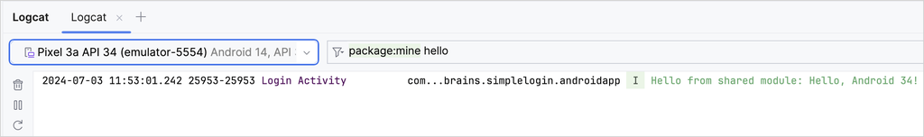

### Make the business logic cross-platform

You can now extract the business logic code to the `commonMain` source set in the Kotlin Multiplatform shared module. This will allow using the code for both Android and iOS.

1. Move the business logic code `com.jetbrains.simplelogin.androidapp.data` from the `app` directory to the `com.jetbrains.simplelogin.shared` package in the `shared/src/commonMain` directory.

[figure not shown]

2. When Android Studio asks what you'd like to do, select to move the package and then approve the refactoring.

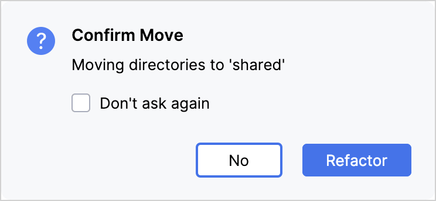

3. Ignore all warnings about platform-dependent code and click Refactor Anyway.

[figure not shown]

4. Remove Android-specific code by replacing it with cross-platform Kotlin code or connecting to Android-specific APIs using expected and actual declarations. See the following sections for details:

#### Replace Android-specific code with cross-platform code

   To make your code work well on both Android and iOS, replace all JVM dependencies with Kotlin dependencies in the moved `data` directory wherever possible.
   1. In the `LoginDataValidator` class, replace the `Patterns` class from the `android.utils` package with a Kotlin regular expression matching the pattern for email validation:

      ```
      // Before
      private fun isEmailValid(email: String) = Patterns.EMAIL_ADDRESS.matcher(email).matches()
      ```

      ```
      // After
      private fun isEmailValid(email: String) = emailRegex.matches(email)

      companion object {
          private val emailRegex =
              ("[a-zA-Z0-9\\+\\.\\_\\%\\-\\+]{1,256}" +
                  "\\@" +
                  "[a-zA-Z0-9][a-zA-Z0-9\\-]{0,64}" +
                  "(" +
                  "\\." +
                  "[a-zA-Z0-9][a-zA-Z0-9\\-]{0,25}" +
                  ")+").toRegex()
      }
      ```

   2. Remove the import directive for the `Patterns` class:

      ```
      import android.util.Patterns
      ```

   4. Remove the import directive for `IOException` as well:

      ```
      import java.io.IOException
      ```

#### Implement platform-specific UUID generation

   In the `LoginDataSource` class, a universally unique identifier (UUID) for `fakeUser` is generated using the `java.util.UUID` class, which is not available for iOS.

   ```
   val fakeUser = LoggedInUser(java.util.UUID.randomUUID().toString(), "Jane Doe")
   ```

   Even though the Kotlin standard library provides a class for UUID generation, let's use platform-specific functionality for this case to practice doing that.

   Provide the `expect` declaration for the `randomUUID()` function in the shared code and its `actual` implementations for each platform – Android and iOS – in the corresponding source sets. You can learn more about connecting to platform-specific APIs.
   1. Change the `java.util.UUID.randomUUID()` call in the `login()` function to a `randomUUID()` call, which you will implement for each platform:

      ```
      val fakeUser = LoggedInUser(randomUUID(), "Jane Doe")
      ```

   2. Create the `Utils.kt` file in the `com.jetbrains.simplelogin.shared` package of the `shared/src/commonMain` directory and provide the `expect` declaration:

      ```
      package com.jetbrains.simplelogin.shared

      expect fun randomUUID(): String
      ```

   3. Create the `Utils.android.kt` file in the `com.jetbrains.simplelogin.shared` package of the `shared/src/androidMain` directory and provide the `actual` implementation for `randomUUID()` in Android:

      ```
      package com.jetbrains.simplelogin.shared

      import java.util.*

      actual fun randomUUID() = UUID.randomUUID().toString()
      ```

   4. Create the `Utils.ios.kt` file in the `com.jetbrains.simplelogin.shared` of the `shared/src/iosMain` directory and provide the `actual` implementation for `randomUUID()` in iOS:

      ```
      package com.jetbrains.simplelogin.shared

      import platform.Foundation.NSUUID

      actual fun randomUUID(): String = NSUUID().UUIDString()
      ```

   5. Import the `randomUUID` function in the `LoginDataSource.kt` file of the `shared/src/commonMain` directory:

      ```
      import com.jetbrains.simplelogin.shared.randomUUID
      ```

Now, Kotlin will use platform-specific implementations of UUID for Android and iOS.

### Run your cross-platform application on Android

Run the `app` run configuration to make sure that the Android app works just as it did before.

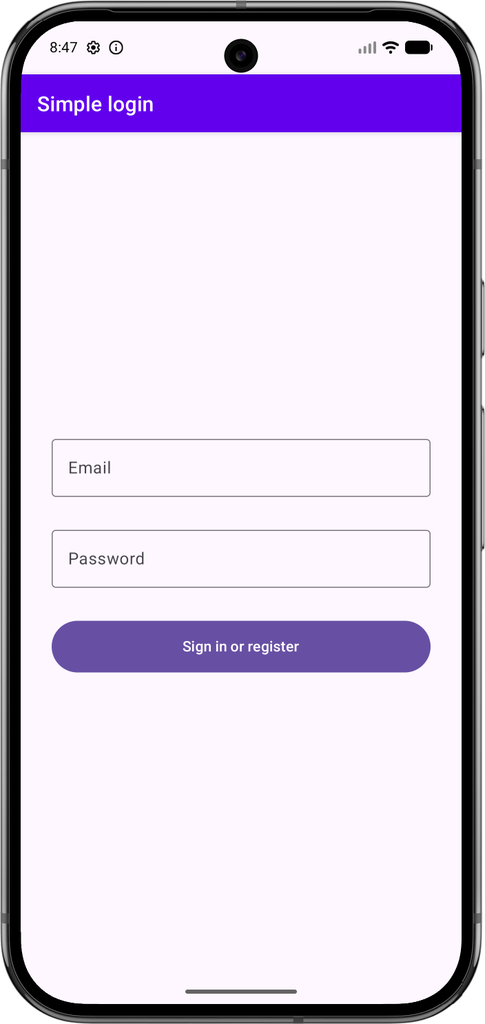

## Make your cross-platform application work on iOS

Once you've made your Android application cross-platform, you can create an iOS application and reuse the shared business logic in it.

1. Create an iOS project in Xcode
2. Configure the iOS project to use a KMP framework
3. Set up an iOS run configuration in Android Studio
4. Use the shared module in the iOS project

### Create an iOS project in Xcode

1. In Xcode, click File | New | Project.
2. In the dialogue, switch to the iOS tab:

[figure not shown]

3. Select the App template, then click Next.
4. As the product name, specify "simpleLoginIOS" and click Next.

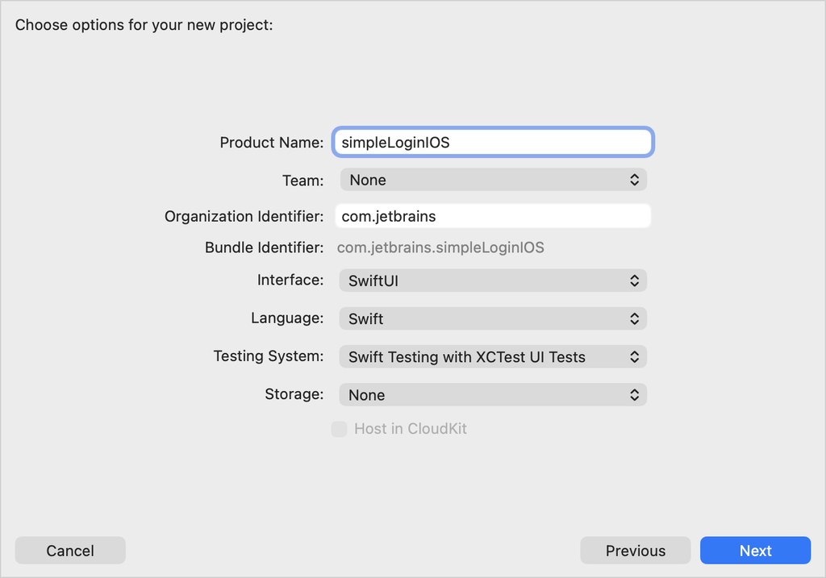

5. As the location for your project, select the directory that stores your cross-platform application, for example, `kmp-integration-sample`.

   In Android Studio, you'll get the following structure:

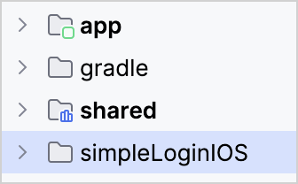

6. For consistency with other top-level directories of your cross-platform project, close Xcode and rename the `simpleLoginIOS` directory to `iosApp`.

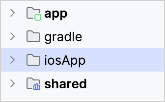

### Configure the iOS project to use a KMP framework

You can set up integration between the iOS app and the framework built by Kotlin Multiplatform directly.

1. In Android Studio, right-click the `iosApp/simpleLoginIOS.xcodeproj` directory and select Open In | Open In Associated Application to open the iOS project in Xcode.
2. In Xcode, click the name of the project in the Project navigator to open the iOS project settings.
3. In the Targets section on the left, select simpleLoginIOS, then click the Build Phases tab.
4. Click the + icon and select New Run Script Phase.

[figure not shown]

5. Paste the following script in the run script field:

   ```
   if [ "YES" = "$OVERRIDE_KOTLIN_BUILD_IDE_SUPPORTED" ]; then
       echo "Skipping Gradle build task invocation due to OVERRIDE_KOTLIN_BUILD_IDE_SUPPORTED environment variable set to \"YES\""
       exit 0
   fi
   cd "$SRCROOT/.."
   ./gradlew :shared:embedAndSignAppleFrameworkForXcode
   ```

6. Disable Based on dependency analysis option. This ensures that Xcode runs the script during every build and doesn't warn about missing output dependencies every time.

[figure not shown]

7. Move the Run Script phase higher, placing it before the Compile Sources phase:

[figure not shown]

8. On the Build Settings tab, disable the User Script Sandboxing option under Build Options:

[figure not shown]

9. On the Info tab, add a custom `CADisableMinimumFrameDurationOnPhone` property and set it to `YES` to enable the high refresh rates on iOS.
10. On the Signing & Capabilities tab, select your development team or create one if you haven't already. This enables signing the `shared` framework produced by the KMP module.

    Here you should also make sure that Bundle Identifier is set to a unique value, or Xcode may fail the build.
11. Build the project in Xcode (Product | Build in the main menu). If everything is configured correctly, the project should build successfully (you can safely ignore the "build phase will be run during every build" warning)

### Set up an iOS run configuration in Android Studio

Once you've made sure that Xcode is set up correctly, return to Android Studio:

1. Select File | Sync Project with Gradle Files in the main menu. Android Studio automatically generates a run configuration called simpleLoginIOS.

   Android Studio automatically generates a run configuration called simpleLoginIOS and marks the `iosApp` directory as a linked Xcode project.
2. In the list of run configurations, select simpleLoginIOS. Choose an iOS emulator and then click Run to check that the iOS run configuration works correctly.

[figure not shown]

### Use the shared module in the iOS project

The `shared/build.gradle.kts` file defines the `binaries.framework.baseName` property for each iOS target as `sharedKit`. This is the name of the framework that Kotlin Multiplatform builds for the iOS app to consume.

To test the integration, add a call to common code in Swift code:

1. In Android Studio, open the `iosApp/simpleloginIOS/ContentView.swift` file and import the framework:

   ```
   import sharedKit
   ```

2. To check that it is properly connected, update the code of the `ContentView` structure to use the `greet()` function from the `shared` module:

   ```
   struct ContentView: View {
       var body: some View {
           Text(Greeting().greet())
           .padding()
       }
   }
   ```

3. Run the app using the Android Studio iOS run configuration to see the result:

[figure not shown]

   ```
   import SwiftUI
   import sharedKit

   @main
   struct SimpleLoginIOSApp: App {
       var body: some Scene {
           WindowGroup {
               ContentView(viewModel: .init(loginRepository: LoginRepository(dataSource: LoginDataSource()), loginValidator: LoginDataValidator()))
           }
       }
   }
   ```

6. Run the iOS run configuration again to see that the iOS app shows the login form.
7. Enter "Jane" as the username and "password" as the password.
8. As you have set up the integration earlier, the iOS app validates input using common code:

[figure not shown]

## Enjoy the results – update the logic only once

Now your application is cross-platform. You can update the business logic in the `shared` module and see results on both Android and iOS.

1. Change the validation logic for a user's password: "password" shouldn't be a valid option. To do that, update the `checkPassword()` function of the `LoginDataValidator` class (to find it quickly, press `Shift` twice, paste the name of the class, and switch to the Classes tab):

   ```
   package com.jetbrains.simplelogin.shared.data

   class LoginDataValidator {
   //...
       fun checkPassword(password: String): Result {
           return when {
               password.length < 5 -> Result.Error("Password must be >5 characters")
               password.lowercase() == "password" -> Result.Error("Password shouldn't be \"password\"")
               else -> Result.Success
           }
       }
   //...
   }
   ```

2. Run both the iOS and Android applications from Android Studio to see the changes (the iOS error message appears when you tap the red warning triangle):

[figure not shown]

You can review the [final code for this tutorial](https://github.com/Kotlin/kmp-integration-sample/tree/final).

## What else to share?

You've shared the business logic of your application, but you can also decide to share other layers of your application. For example, the `ViewModel` class code is almost the same for [Android](https://github.com/Kotlin/kmp-integration-sample/blob/final/app/src/main/java/com/jetbrains/simplelogin/androidapp/ui/login/LoginViewModel.kt) and [iOS applications](https://github.com/Kotlin/kmp-integration-sample/blob/final/iosApp/SimpleLoginIOS/ContentView.swift#L84), and you can share it if your mobile applications should have the same presentation layer.

## What's next?

Once you've made your Android application cross-platform, you can move on and:

- Add dependencies on multiplatform libraries
- Add Android dependencies
- Add iOS dependencies

You can use Compose Multiplatform to create a unified UI across all platforms:

- Learn about Compose Multiplatform and Jetpack Compose
- Explore available resources for Compose Multiplatform
- Create an app with shared logic and UI

You can also check out community resources:

- [Video: How to migrate an Android project to Kotlin Multiplatform](https://www.youtube.com/watch?v=vb-Pt8SdfEE&t=1s)
- [Video: 3 ways to get your Kotlin JVM code ready for Kotlin Multiplatform](https://www.youtube.com/watch?v=X6ckI1JWjqo)

21 July 2026

© 2010–2026 JetBrains s.r.o. and Kotlin Programming Language contributors  
Licensed under the Apache License, Version 2.0.  
https://kotlinlang.org/docs/multiplatform/multiplatform-integrate-in-existing-app.html